# SPPH 504 Section 007 Lab 6 (part 1) Missing data and Imputation

Ehsan Karim, ehsan.karim@ubc.ca

01 May 2020

Missing data is common in health research. In this lab, we will learn different ways to impute the values for missing values using the package `mice`. In this lab discussion, we used the materials from (Van Buuren 2018). Below we also citet he section numbers.

# 1 Type of missing data

- Ref: (Van Buuren 2018), Section 1.2

In this section, we are going to introduce three types of missing data that we will encounter in data analysis.

- Missing completely at random (MCAR)
  - missing data is completely independent of the measured and unmeasured variables
  - if you could compare the individuals with the missing information with individuals with completed information, they do not differ substantially.
  - often unrealistic assumption
- Missing at random (MAR)
  - the missing data is related to variables that are all measured
- Missing not at random (MNAR)
  - If the missing data is related to unmeasured variables, we say the missing is not at random.

**Analysis strategy depening on missingness**

- If the data is MCAR, we may still use complete-case analysis which will not introduce any bias. However, the standard error of the estimate may go up, which results in a wider confidence interval as we have missed some information.
- If the data is MNAR, we do not have a good way to address it in the analysis and the estimates, of course, will be biased.
- If the data is MAR, we could use imputation to impute the missing values. The following parts of this lab are to introduce the methods of imputing missing values.

# 2 Data imputation

## 2.1 Getting to know the data

In this section, we are going to introduce a different method of imputing missing values. We will use the `nhanes` dataset from `mice` package as an example.

```r
require(VIM)
data(nhanes)# built-in data
nhanes
```

```
##    age  bmi hyp chl
## 1    1   NA  NA  NA
## 2    2 22.7   1 187
## 3    1   NA   1 187
## 4    3   NA  NA  NA
## 5    1 20.4   1 113
## 6    3   NA  NA 184
## 7    1 22.5   1 118
## 8    1 30.1   1 187
## 9    2 22.0   1 238
## 10   2   NA  NA  NA
## 11   1   NA  NA  NA
## 12   2   NA  NA  NA
## 13   3 21.7   1 206
## 14   2 28.7   2 204
## 15   1 29.6   1  NA
## 16   1   NA  NA  NA
## 17   3 27.2   2 284
## 18   2 26.3   2 199
## 19   1 35.3   1 218
## 20   3 25.5   2  NA
## 21   1   NA  NA  NA
## 22   1 33.2   1 229
## 23   1 27.5   1 131
## 24   3 24.9   1  NA
## 25   2 27.4   1 186
```

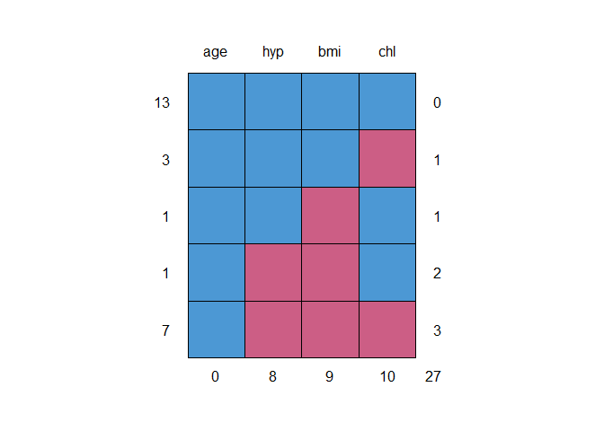

```
##    age hyp bmi chl
## 13   1   1   1   1  0
## 3    1   1   1   0  1
## 1    1   1   0   1  1
## 1    1   0   0   1  2
## 7    1   0   0   0  3
##      0   8   9  10 27
```

```r
md.pattern(nhanes) # Inspect the missing data pattern
```

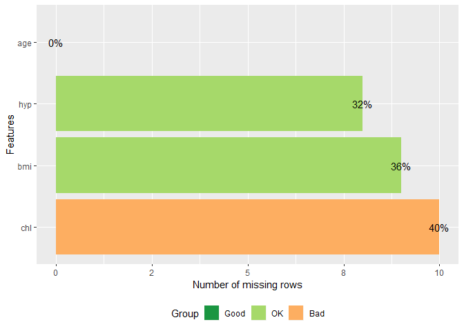

```r
# last col gives missing counts for each variables
# possible missingness (0,1) pattern and counts
# e,g, 7 cases with only age present
require(DataExplorer)
plot_missing(nhanes)
```

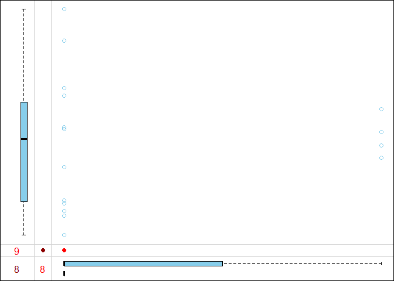

```r
# check the missingness
require(VIM)
marginplot(nhanes[, c("hyp", "bmi")])
```

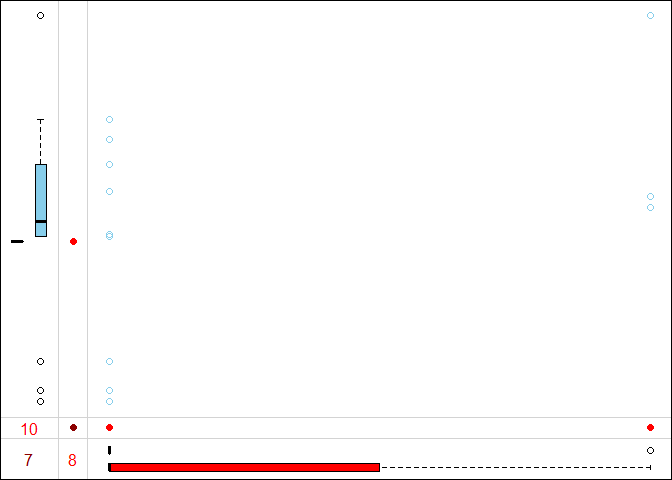

```r
marginplot(nhanes[, c("hyp", "chl")])
```

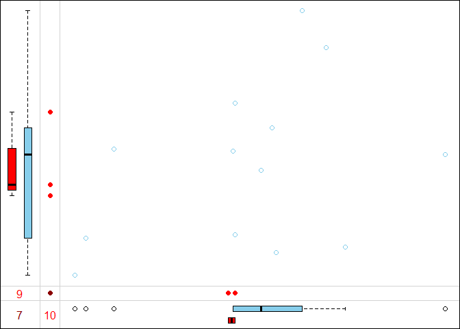

```r
marginplot(nhanes[, c("chl", "bmi")])
```

```r
# distribution of observed data given the other variable is observed
# for MCAR, blue and red box plots should be similar
```